# Individual Assignment_01

Naoya Kinoshita

2023-05-16

```r
library(nycflights13)
library(tidyverse)
library(dplyr)
library(knitr)
library(kableExtra)
```

### Problem 01

#### Use logical operators to find flights that

#### Q1: Had an arrival delay of two or more hours (> 120 minutes)

#### Q1: Answer: 10,034 Flights

#### Q2: Flew to Houston (IAH or HOU) Were operated by United (UA), American (AA), or Delta (DL)

#### Q2: Answer: 7,198 Flights

#### Q3: Departed in summer (July, August, and September)

#### Q3: Answer: 86,326 Flights

#### Q4: Arrived more than two hours late, but didn’t leave late

#### Q4: Answer: 29 Flights

#### Q5: Were delayed by at least an hour, but made up over 30 minutes in flight

```r
# Q1: The flights delayed more than 120 minutes
q1_flights <- flights %>%
  filter(arr_delay > 120)

# Q2: The flights whihch destination are Huston and operated by UA, AA, or DL
q2_flights <- flights %>%
  filter(dest %in% c("IAH", "HOU"),
         carrier %in% c("UA", "AA", "DL"))

# Q3: The flights depearted in July, August, September
q3_flights <- flights %>%
  filter(month %in% c(7, 8, 9))

# Q4: Arrived more than two hours late, but didn’t leave late Were delayed by at least an hour, but made up over 30 minutes in flight
q4_flights <- flights %>%
  filter(arr_delay > 120,
         dep_delay <= 0)

# Q5: Were delayed by at least an hour, but made up over 30 minutes in fl ight
q5_flights <- flights %>%
  filter(dep_delay >= 60,
         (arr_delay - dep_delay) > 30)

# showing answer to each question
answer <- data.frame(
  Q1 = nrow(q1_flights),
  Q2 = nrow(q2_flights),
  Q3 = nrow(q3_flights),
  Q4 = nrow(q4_flights),
  Q5 = nrow(q5_flights)
)

answer
```

```
##      Q1   Q2    Q3 Q4   Q5
## 1 10034 7198 86326 29 1948
```

### Problem 02

#### Question : What months had the highest and lowest proportion of cancelled flights? Interpret any seasonal patterns. To determine if a flight was cancelled use the following code

#### Answer : When organizing the data and examining the bar graph, it was found that the month with the highest percentage of canceled flights was February, at 5.371%. Conversely, the month with the lowest percentage of canceled flights was October, at 0.938%.

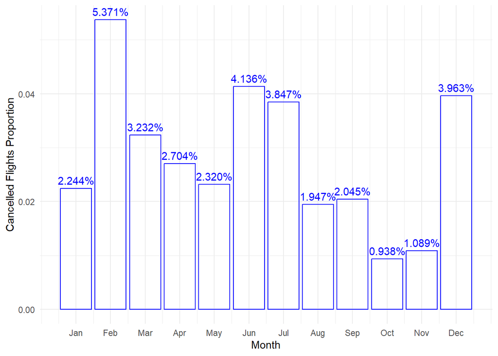

```r
# calculating the proportion of flights that cancelled
cancelled_proportion <- flights %>%
  group_by(month) %>%
  summarise(cancelled_proportion = sum(is.na(dep_delay) | is.na(arr_delay)) / n())

# Making bar graph
ggplot(cancelled_proportion, aes(x = month, y = cancelled_proportion)) +
  geom_bar(stat = "identity", fill = "transparent", color = "blue") +
  geom_text(aes(label = scales::percent(cancelled_proportion)), vjust = -0.5, color = "blue") +
  scale_x_continuous(breaks = 1:12, labels = month.abb) +
  labs(x = "Month", y = "Cancelled Flights Proportion") +
  theme_minimal()
```

### Understanding data

```r
dplyr::glimpse(flights)
```

```
## Rows: 336,776
## Columns: 19
## $ year           <int> 2013, 2013, 2013, 2013, 2013, 2013, 2013, 2013, 2013, 2…
## $ month          <int> 1, 1, 1, 1, 1, 1, 1, 1, 1, 1, 1, 1, 1, 1, 1, 1, 1, 1, 1…
## $ day            <int> 1, 1, 1, 1, 1, 1, 1, 1, 1, 1, 1, 1, 1, 1, 1, 1, 1, 1, 1…
## $ dep_time       <int> 517, 533, 542, 544, 554, 554, 555, 557, 557, 558, 558, …
## $ sched_dep_time <int> 515, 529, 540, 545, 600, 558, 600, 600, 600, 600, 600, …
## $ dep_delay      <dbl> 2, 4, 2, -1, -6, -4, -5, -3, -3, -2, -2, -2, -2, -2, -1…
## $ arr_time       <int> 830, 850, 923, 1004, 812, 740, 913, 709, 838, 753, 849,…
## $ sched_arr_time <int> 819, 830, 850, 1022, 837, 728, 854, 723, 846, 745, 851,…
## $ arr_delay      <dbl> 11, 20, 33, -18, -25, 12, 19, -14, -8, 8, -2, -3, 7, -1…
## $ carrier        <chr> "UA", "UA", "AA", "B6", "DL", "UA", "B6", "EV", "B6", "…
## $ flight         <int> 1545, 1714, 1141, 725, 461, 1696, 507, 5708, 79, 301, 4…
## $ tailnum        <chr> "N14228", "N24211", "N619AA", "N804JB", "N668DN", "N394…
## $ origin         <chr> "EWR", "LGA", "JFK", "JFK", "LGA", "EWR", "EWR", "LGA",…
## $ dest           <chr> "IAH", "IAH", "MIA", "BQN", "ATL", "ORD", "FLL", "IAD",…
## $ air_time       <dbl> 227, 227, 160, 183, 116, 150, 158, 53, 140, 138, 149, 1…
## $ distance       <dbl> 1400, 1416, 1089, 1576, 762, 719, 1065, 229, 944, 733, …
## $ hour           <dbl> 5, 5, 5, 5, 6, 5, 6, 6, 6, 6, 6, 6, 6, 6, 6, 5, 6, 6, 6…
## $ minute         <dbl> 15, 29, 40, 45, 0, 58, 0, 0, 0, 0, 0, 0, 0, 0, 0, 59, 0…
## $ time_hour      <dttm> 2013-01-01 05:00:00, 2013-01-01 05:00:00, 2013-01-01 0…
```

```r
flights %>%
  #count() is the same as group_by()... summarise()
  #sort=TRUE` gives table in descending order
  count(origin, sort = TRUE) %>%

  # mutate() generates a new column called `prop` which is the proportion of flights
  # calculated as number of flights `n` divided by the `sum(n)`
  mutate(prop = n/sum(n))
```

```
## # A tibble: 3 × 3
##   origin      n  prop
##   <chr>   <int> <dbl>
## 1 EWR    120835 0.359
## 2 JFK    111279 0.330
## 3 LGA    104662 0.311
```

```r
# Which origin airports had the greatest number of flights?
origin <- flights %>%
  group_by(origin) %>%
  summarise(total_flights = n()) %>%
  arrange(desc(total_flights))
  kable(origin)
```

| origin | total_flights |
| --- | --- |
| EWR | 120835 |
| JFK | 111279 |
| LGA | 104662 |

```r
# What was the longest arr_delay?
longest_arr_delay <- flights %>%
  filter(arr_delay == max(arr_delay, na.rm = TRUE)) %>%
  select(year, month, day, dep_time, sched_dep_time, dep_delay, arr_time, sched_arr_time, arr_delay, carrier, flight, tailnum, origin, dest, air_time, distance, hour, minute, time_hour)

kable(longest_arr_delay)
```

| year | month | day | dep_time | sched_dep_time | dep_delay | arr_time | sched_arr_time | arr_delay | carrier | flight | tailnum | origin | dest | air_time | distance | hour | minute | time_hour |
| --- | --- | --- | --- | --- | --- | --- | --- | --- | --- | --- | --- | --- | --- | --- | --- | --- | --- | --- |
| 2013 | 1 | 9 | 641 | 900 | 1301 | 1242 | 1530 | 1272 | HA | 51 | N384HA | JFK | HNL | 640 | 4983 | 9 | 0 | 2013-01-09 09:00:00 |

```r
# What was the average arr_delay for a carrier, say UA?
average_arr_delay_UA <- flights %>%
  filter(carrier == "UA") %>%
  summarise(average_arr_delay = mean(arr_delay, na.rm = TRUE))

kable(average_arr_delay_UA)
```

| average_arr_delay |
| --- |
| 3.558011 |

```r
# What was the average dep_delay and arr_delay for all carriers, ranked in descending order of number of flights operated by each carrier?
average_delay_by_carrier <- flights %>%
  group_by(carrier) %>%
  summarise(
    average_dep_delay = mean(dep_delay, na.rm = TRUE),
    average_arr_delay = mean(arr_delay, na.rm = TRUE),
    total_flights = n()
  ) %>%
  arrange(desc(total_flights))

kable(average_delay_by_carrier)
```

| carrier | average_dep_delay | average_arr_delay | total_flights |
| --- | --- | --- | --- |
| UA | 12.106073 | 3.5580111 | 58665 |
| B6 | 13.022522 | 9.4579733 | 54635 |
| EV | 19.955390 | 15.7964311 | 54173 |
| DL | 9.264504 | 1.6443409 | 48110 |
| AA | 8.586016 | 0.3642909 | 32729 |
| MQ | 10.552041 | 10.7747334 | 26397 |
| US | 3.782418 | 2.1295951 | 20536 |
| 9E | 16.725769 | 7.3796692 | 18460 |
| WN | 17.711744 | 9.6491199 | 12275 |
| VX | 12.869421 | 1.7644644 | 5162 |
| FL | 18.726075 | 20.1159055 | 3260 |
| AS | 5.804775 | -9.9308886 | 714 |
| F9 | 20.215543 | 21.9207048 | 685 |
| YV | 18.996330 | 15.5569853 | 601 |
| HA | 4.900585 | -6.9152047 | 342 |
| OO | 12.586207 | 11.9310345 | 32 |

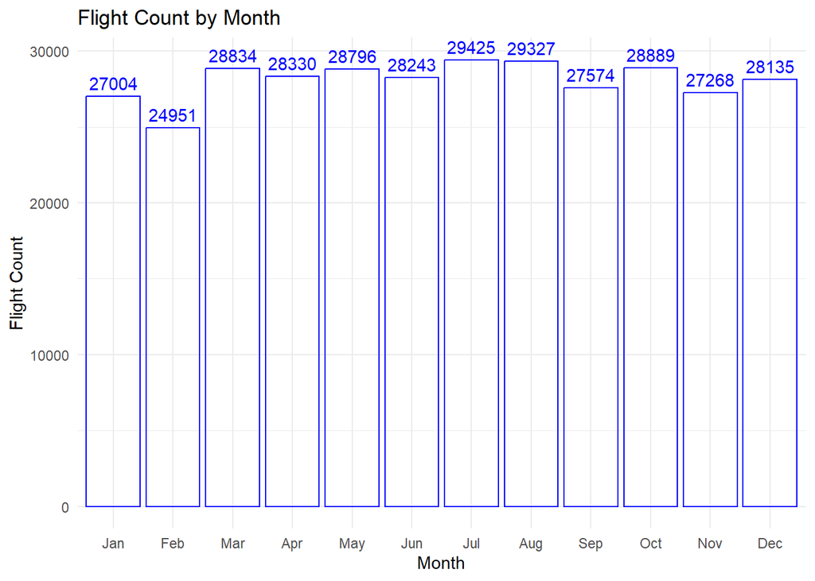

```r
# Understanding Data

# Definition of Month
month_names <- c("Jan", "Feb", "Mar", "Apr", "May", "Jun",
                 "Jul", "Aug", "Sep", "Oct", "Nov", "Dec")

# Collecting data by month
flight_counts <- flights %>%
  mutate(month = month) %>%
  group_by(month) %>%
  summarise(total_flights = n()) %>%
  mutate(month = factor(month, levels = 1:12, labels = month_names)) %>%
  arrange(month)

# making a table
flight_table <- flight_counts %>%
  spread(key = month, value = total_flights, fill = 0)

# making a bar graph
ggplot(flight_counts, aes(x = month, y = total_flights)) +
  geom_bar(stat = "identity", fill = "transparent", color = "blue") +
  geom_text(aes(label = total_flights), vjust = -0.5, color = "blue") +
  labs(x = "Month", y = "Flight Count", title = "Flight Count by Month") +
  theme_minimal()
```

```r
# collecting data by origin
origin_counts <- flights %>%
  group_by(month, origin) %>%
  summarise(total_flights = n()) %>%
  spread(key = origin, value = total_flights, fill = 0)
# collecting data by destination
dest_counts <- flights %>%
  group_by(month, dest) %>%
  summarise(total_flights = n()) %>%
  spread(key = dest, value = total_flights, fill = 0)
# prints by Origin
print(origin_counts)
```

```
## # A tibble: 12 × 4
## # Groups:   month [12]
##    month   EWR   JFK   LGA
##    <int> <dbl> <dbl> <dbl>
##  1     1  9893  9161  7950
##  2     2  9107  8421  7423
##  3     3 10420  9697  8717
##  4     4 10531  9218  8581
##  5     5 10592  9397  8807
##  6     6 10175  9472  8596
##  7     7 10475 10023  8927
##  8     8 10359  9983  8985
##  9     9  9550  8908  9116
## 10    10 10104  9143  9642
## 11    11  9707  8710  8851
## 12    12  9922  9146  9067
```

```r
# prints by Dest
print(dest_counts)
```

```
## # A tibble: 12 × 106
## # Groups:   month [12]
##    month   ABQ   ACK   ALB   ANC   ATL   AUS   AVL   BDL   BGR   BHM   BNA   BOS
##    <int> <dbl> <dbl> <dbl> <dbl> <dbl> <dbl> <dbl> <dbl> <dbl> <dbl> <dbl> <dbl>
##  1     1     0     0    64     0  1396   169     2    37     0    25   399  1245
##  2     2     0     0    58     0  1267   167     0    46     0    23   387  1182
##  3     3     0     0    57     0  1448   273     0    62     2    26   501  1324
##  4     4     9     0    13     0  1490   209     3    61    29    26   515  1305
##  5     5    31    21    59     0  1499   204    35    57    29    27   563  1327
##  6     6    30    43    34     0  1438   203    40    48    28    27   556  1312
##  7     7    31    66    15     4  1511   213    40     2    30    29   574  1378
##  8     8    31    67    20     4  1507   211    35    50    30    30   567  1377
##  9     9    30    45    20     0  1364   205    30    39    56    25   568  1307
## 10    10    31    23     1     0  1448   214    31     9    60    27   578  1357
## 11    11    30     0    46     0  1384   186    30     3    55    22   553  1235
## 12    12    31     0    52     0  1463   185    29    29    56    10   572  1159
## # ℹ 93 more variables: BQN <dbl>, BTV <dbl>, BUF <dbl>, BUR <dbl>, BWI <dbl>,
## #   BZN <dbl>, CAE <dbl>, CAK <dbl>, CHO <dbl>, CHS <dbl>, CLE <dbl>,
## #   CLT <dbl>, CMH <dbl>, CRW <dbl>, CVG <dbl>, DAY <dbl>, DCA <dbl>,
## #   DEN <dbl>, DFW <dbl>, DSM <dbl>, DTW <dbl>, EGE <dbl>, EYW <dbl>,
## #   FLL <dbl>, GRR <dbl>, GSO <dbl>, GSP <dbl>, HDN <dbl>, HNL <dbl>,
## #   HOU <dbl>, IAD <dbl>, IAH <dbl>, ILM <dbl>, IND <dbl>, JAC <dbl>,
## #   JAX <dbl>, LAS <dbl>, LAX <dbl>, LEX <dbl>, LGA <dbl>, LGB <dbl>, …
```